# R Workshop for Applied Research Projects

2026-05-08

## Workshop goals

- Understand the key differences between R and Stata.
- Write reproducible scripts instead of isolated console commands.
- Manipulate data with `dplyr`.
- Produce charts, regressions and simple output tables.
- Know where to find help and how to structure a small project.

## Agenda

1. Interface, help and project structure.
2. Packages, objects and syntax.
3. Data import and data manipulation.
4. Charts and tables.
5. Econometric estimation.
6. Dates, strings and wrap-up exercise.

## RStudio interface

- **Script**: saved, versionable and rerunnable source code.
- **Console**: interactive execution and error messages.
- **Environment**: objects currently stored in memory.
- **Files / Plots / Packages / Help**: outputs, files and documentation.

Useful habit: anything you want to keep should be written in a script, not only typed in the console.

## Help and documentation

```r
?lm
help("merge")
example(mean)
```

Useful resources:

- [R for Data Science](https://r4ds.hadley.nz/)
- [Stata2R](https://stata2r.github.io/)
- [UtilitR](https://www.utilitr.org/)

## Packages

A package adds functions, datasets or methods.

```r
install.packages("dplyr")  # once per machine
library(dplyr)             # in each new session
```

For training, listing required packages in the README or an install script prevents many last-minute issues.

## Objects and assignment

```r
baguette_price <- 0.95
quantities <- c(1, 2, 3)
spending <- baguette_price * quantities
spending
```

```
## [1] 0.95 1.90 2.85
```

In R, results are usually assigned to objects with `<-`. The `=` sign often works, but `<-` remains the clearest convention.

## Useful differences with Stata

| Stata | R |
| --- | --- |
| One active dataset in memory | Several objects at the same time |
| `use`, `save` | `read.csv()`, `write.csv()`, `readxl::read_xlsx()` |
| `gen`, `replace` | `mutate()` |
| `keep if` | `filter()` |
| `collapse` | `group_by()` then `summarise()` |
| `merge` | `left_join()`, `inner_join()`, `full_join()` |

## Importing a file

```r
economy <- read.csv("data/sample_economy.csv")
head(economy)
```

```
##   country year      sector employment wage price_index consumption
## 1  France 2020    Industry       3100 37.2       101.4       220.5
## 2  France 2020    Services       8200 34.8       101.4       516.2
## 3  France 2020 Agriculture        640 25.1       101.4        41.0
## 4  France 2021    Industry       3180 38.1       103.1       229.8
## 5  France 2021    Services       8460 35.7       103.1       538.4
## 6  France 2021 Agriculture        630 25.8       103.1        42.3
```

For Excel files:

```r
readxl::read_xlsx("data/my_file.xlsx", sheet = "Sheet1")
```

## Selecting and filtering

### Stata

```stata
keep if country == "France" & year >= 2021
keep country year sector wage
```

### R

```r
economy |>
  filter(country == "France", year >= 2021) |>
  select(country, year, sector, wage)
```

```
##   country year      sector wage
## 1  France 2021    Industry 38.1
## 2  France 2021    Services 35.7
## 3  France 2021 Agriculture 25.8
## 4  France 2022    Industry 40.0
## 5  France 2022    Services 37.6
## 6  France 2022 Agriculture 27.2
```

## Creating a variable

### Stata

```stata
gen real_wage = wage / price_index * 100
```

### R

```r
economy <- economy |>
  mutate(real_wage = wage / price_index * 100)

economy |>
  select(country, year, sector, real_wage) |>
  head()
```

```
##   country year      sector real_wage
## 1  France 2020    Industry  36.68639
## 2  France 2020    Services  34.31953
## 3  France 2020 Agriculture  24.75345
## 4  France 2021    Industry  36.95441
## 5  France 2021    Services  34.62658
## 6  France 2021 Agriculture  25.02425
```

## Aggregating

### Stata

```stata
collapse (mean) mean_wage = wage, by(country year)
```

### R

```r
country_year <- economy |>
  group_by(country, year) |>
  summarise(mean_wage = mean(wage), .groups = "drop")

country_year
```

```
## # A tibble: 9 × 3
##   country  year mean_wage
##   <chr>   <int>     <dbl>
## 1 France   2020      32.4
## 2 France   2021      33.2
## 3 France   2022      34.9
## 4 Germany  2020      33.4
## 5 Germany  2021      34.1
## 6 Germany  2022      36.0
## 7 Italy    2020      27.8
## 8 Italy    2021      28.5
## 9 Italy    2022      30.0
```

## Joining two tables

```r
population <- data.frame(
  country = c("France", "Germany", "Italy"),
  population_m = c(67.8, 83.2, 59.0)
)

country_year |>
  left_join(population, by = "country") |>
  head()
```

```
## # A tibble: 6 × 4
##   country  year mean_wage population_m
##   <chr>   <int>     <dbl>        <dbl>
## 1 France   2020      32.4         67.8
## 2 France   2021      33.2         67.8
## 3 France   2022      34.9         67.8
## 4 Germany  2020      33.4         83.2
## 5 Germany  2021      34.1         83.2
## 6 Germany  2022      36.0         83.2
```

Remember the direction of the join: `left_join(x, y)` keeps all rows from `x`.

## data.table in one sentence

`data.table` is very efficient on large datasets. Its syntax is compact:

```r
library(data.table)
dt <- as.data.table(economy)
dt[country == "France", .(mean_wage = mean(wage)), by = year]
```

```
##     year mean_wage
##    <int>     <num>
## 1:  2020  32.36667
## 2:  2021  33.20000
## 3:  2022  34.93333
```

For beginners, `dplyr` is often easier to read; for massive datasets, `data.table` may become preferable.

## Simple chart

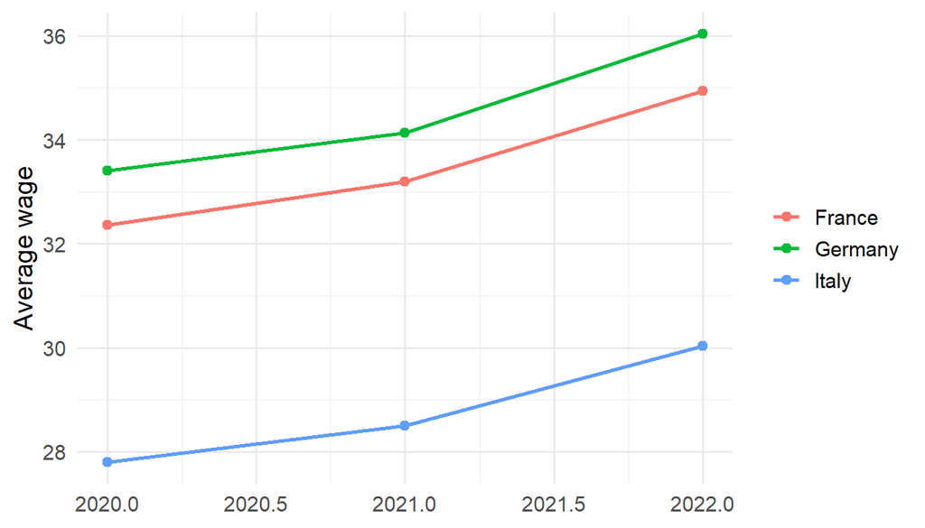

```r
ggplot(country_year, aes(x = year, y = mean_wage, color = country)) +
  geom_line(linewidth = 1) +
  geom_point(size = 2) +
  labs(x = NULL, y = "Average wage", color = NULL)
```

## ggplot2 principles

- `ggplot(data, aes(...))` declares the data and mapped variables.
- `geom_*()` chooses the visual representation: points, lines, bars.
- `labs()`, `scale_*()` and `theme_*()` adjust presentation.
- Each layer is added with `+`.

```r
ggplot(data, aes(x = x, y = y)) +
  geom_point() +
  labs(x = "X", y = "Y")
```

## Linear regression

### Stata

```stata
reg real_wage employment i.sector
```

### Base R

```r
model_lm <- lm(real_wage ~ employment + factor(sector), data = economy)
summary(model_lm)
```

```
##
## Call:
## lm(formula = real_wage ~ employment + factor(sector), data = economy)
##
## Residuals:
##     Min      1Q  Median      3Q     Max
## -3.8674 -1.6908  0.4735  1.4333  2.7922
##
## Coefficients:
##                         Estimate Std. Error t value Pr(>|t|)
## (Intercept)            2.324e+01  7.366e-01  31.553  < 2e-16 ***
## employment             7.674e-04  2.274e-04   3.375  0.00261 **
## factor(sector)Industry 8.481e+00  1.430e+00   5.932 4.78e-06 ***
## factor(sector)Services 2.559e+00  2.291e+00   1.117  0.27562
## ---
## Signif. codes:  0 '***' 0.001 '**' 0.01 '*' 0.05 '.' 0.1 ' ' 1
##
## Residual standard error: 2.164 on 23 degrees of freedom
## Multiple R-squared:  0.8762, Adjusted R-squared:   0.86
## F-statistic: 54.25 on 3 and 23 DF,  p-value: 1.372e-10
```

## Fixed effects with fixest

`fixest` is close in spirit to `reghdfe`: fast, concise and convenient for fixed effects and clustered standard errors.

```r
model_fe <- feols(
  real_wage ~ employment | country + year,
  data = economy,
  vcov = ~ country
)
etable(model_fe)
```

```
##                           model_fe
## Dependent Var.:          real_wage
##
## employment      0.0010** (4.85e-5)
## Fixed-Effects:  ------------------
## country                        Yes
## year                           Yes
## _______________ __________________
## S.E.: Clustered        by: country
## Observations                    27
## R2                         0.61545
## Within R2                  0.54274
## ---
## Signif. codes: 0 '***' 0.001 '**' 0.01 '*' 0.05 '.' 0.1 ' ' 1
```

## Clean output

```r
broom::tidy(model_lm)
```

```
## # A tibble: 4 × 5
##   term                    estimate std.error statistic  p.value
##   <chr>                      <dbl>     <dbl>     <dbl>    <dbl>
## 1 (Intercept)            23.2       0.737        31.6  1.94e-20
## 2 employment              0.000767  0.000227      3.37 2.61e- 3
## 3 factor(sector)Industry  8.48      1.43          5.93 4.78e- 6
## 4 factor(sector)Services  2.56      2.29          1.12 2.76e- 1
```

For a report:

- keep model objects (`model_lm`, `model_fe`);
- generate tables in the script;
- avoid manual copy-paste from the console.

## Dates with lubridate

```r
day <- ymd("2023-02-11")
day
```

```
## [1] "2023-02-11"
```

```r
year(day)
```

```
## [1] 2023
```

```r
month(day)
```

```
## [1] 2
```

`ymd()`, `dmy()` and `mdy()` make the day/month/year order explicit.

## Strings with stringr

```r
text <- "Hello world"
str_replace(text, "world", "universe")
```

```
## [1] "Hello universe"
```

```r
str_sub(text, 1, 5)
```

```
## [1] "Hello"
```

```r
str_detect(text, "Hello")
```

```
## [1] TRUE
```

Mental translation:

- Stata `subinstr()` -> R `str_replace()` or `str_replace_all()`.
- Stata `substr()` -> R `str_sub()`.
- Stata `regexm()` -> R `str_detect()`.

## Web calls and external databases

For DB.NOMICS or other APIs, showing non-executed code keeps slides robust.

```r
library(rdbnomics)
df <- rdbnomics::rdb(ids = "INSEE/CNT-2014-CSI/...")
```

In training, always provide a local fallback file in case the network, proxy or API is unavailable.

## Recommended mini-project

1. Import `data/sample_economy.csv`.
2. Create a real wage variable.
3. Compute average wages by country and year.
4. Plot the time series.
5. Estimate a simple model with fixed effects.
6. Save the chart and the result table.

## Project good practices

```
AtelierR/
  data/
  exercises/
  solutions/
  atelierR.Rmd
  atelierR_en.Rmd
  README.md
```

- Use relative paths from the project root.
- Store lightweight example data in `data/`.
- Keep executable solutions in `solutions/`.
- Document goals, prerequisites and rendering commands in the README.

## Conclusion

R is not only a statistical calculator: it is a project environment.

The main gain over purely interactive work is reproducibility: tomorrow, someone should be able to rerun the script and obtain the same outputs.